# Growth: the Solow model

**NOTE**: The present notebook is coded with [quarto](https://quarto.org/), in the [**R**](https://www.r-project.org/) programming language. The white margin to the right will be used to display code output.

This document relies heavily on the [{**tidyverse**}](https://www.tidyverse.org/) ecosystem of packages. We load the tidyverse below as a prerequisite for the rest of the notebook - along with a few other important libraries.

Because we use WEBR, the notebook takes time to load because it fetches the data from the World Bank API - it thus requires an **internet connexion**.

To install R packages on your own device, use the install.packages() function as below (commented on purpose).

```r
# install.packages("tidyverse")
```

Once they are installed, we can call/load/activate them in the current session.

```r
library(tidyverse)    # Package for data wrangling
library(readxl)       # Package to import MS Excel files
library(latex2exp)    # Package for LaTeX expressions
library(quantmod)     # Package for stock data extraction
library(WDI)          # To access World Bank data
library(gtsummary)    # To format regression output
library(ggsci)        # Color scales
library(tidyfit)      # Enhanced regressions
library(ggrepel)      # Better labels on plots
library(plm)          # Panel models
```

$\rightarrow$ Don’t forget that code flows **sequentially**. A random chunk may not work if the previous ones have have not been executed.

The content of the notebook is heavily inspired from the book [**Advanced Macro-economics - An Easy Guide**](https://press.lse.ac.uk/site/books/m/10.31389/lsepress.ame/).

# 1 Growth: a central question in economics

For decades, economists have sought to understand and explain the **drivers of growth**. Let us understand why by looking at long-run patterns of economic output.

The [**Maddison Project Database**](https://www.rug.nl/ggdc/historicaldevelopment/maddison/releases/maddison-project-database-2020) compiles data for GDP over **long chronological depths**. See the paper [Maddison-style estimates of the evolution of the world economy: A new 2023 update](https://onlinelibrary.wiley.com/doi/10.1111/joes.12618). The [Penn World Tables](https://www.rug.nl/ggdc/productivity/pwt/?lang=en) are also good data sources.

Below, we focus on a subset of countries for which a lot of points are available.

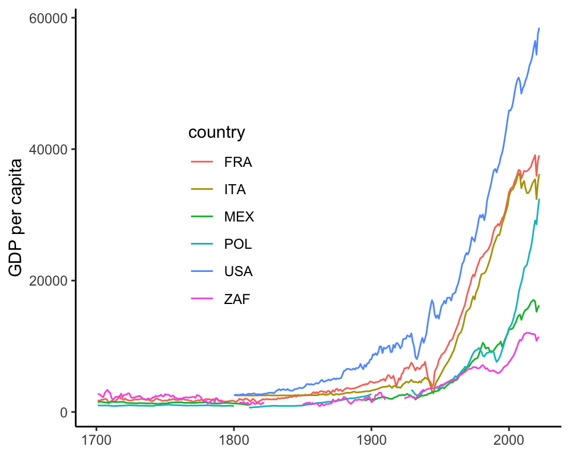

```r
temp <- tempfile()
link <- "https://dataverse.nl/api/access/datafile/421302"
# 2020 version below in comments
#link <- "https://www.rug.nl/ggdc/historicaldevelopment/maddison/data/mpd2020.xlsx"
#lt_gdp <- read_excel(temp, sheet = 3)
#lt_gdp <- read_excel(temp, sheet = 3)
#country_list <- c("France", "United States", "Italy", "Mexico", "Poland", "South Africa")
download.file(link, temp)
lt_gdp <- read_excel(temp, sheet = 3, skip = 2) |>
  pivot_longer(-year, names_to = "country", values_to = "gdppc")

country_list <- c("FRA", "USA", "ITA", "MEX", "POL", "ZAF")

lt_gdp |>
  filter(year > 1700, country %in% country_list) |>
  ggplot(aes(x = year, y = gdppc, color = country)) + geom_line() +
  theme_classic() + ylab("GDP per capita") +
  theme(legend.position = c(0.3, 0.5),
        axis.title.x = element_blank())
```

What we see is an exponential pattern in growth. And the central question is: **how come**???  
The purpose of the sessions to come will be to propose theoretical models that seek to reproduce this salient fact.

A few interesting additional resources:

- for long term estimates of GDP, we refer to this [**tool**](https://philmkoch.github.io/historicalGDPpc_app/), [**data**](https://github.com/philmkoch/historicalGDPpc), and the corresponding [paper](https://www.pnas.org/doi/10.1073/pnas.2402060121).
- see also [When Did Growth Begin? New Estimates of Productivity Growth in England from 1250 to 1870](https://academic.oup.com/qje/article-abstract/140/2/835/7933323): “*We find that productivity growth was zero before 1600. Productivity growth began in 1600—almost a century before the Glorious Revolution. Thus, the onset of productivity growth preceded the bourgeois institutional reforms of seventeenth-century England. We estimate productivity growth of 2% per decade between 1600 and 1800, increasing to 5% per decade between 1810 and 1860. Much of the increase in output growth during the Industrial Revolution is explained by structural change — the falling importance of land in production—rather than faster productivity growth.*”
- granular GDP growth & per capita values for [European regions](https://ec.europa.eu/eurostat/en/web/products-eurostat-news/w/ddn-20260210-2):

[figure not shown]

# 2 The baseline model

In this section, we present the [Solow model of growth](https://academic.oup.com/qje/article-abstract/70/1/65/1903777).

## 2.1 Notations and first properties

We model aggregate output $Y$ as a function of two inputs: capital $K$ and labor $L$:

$$Y=F(K,L),$$
where the function $F$ must satisfy a set of properties (which define **neoclassical production functions** and are sometimes called the **[Inada conditions](https://en.wikipedia.org/wiki/Inada_conditions)**):

1. **first**, $\frac{\partial F}{\partial K}>0$ and $\frac{\partial F}{\partial L}>0$: with more capital or more labor, we are able to produce more (makes sense!).
2. **second**, however: $\frac{\partial^2 F}{\partial^2 K}<0$ and $\frac{\partial^2 F}{\partial L^2}<0$: the returns to increasing inputs are diminishing. Increasing one input will only lead you so far…
3. **third**, $F$ exhibits **constant returns to scale**: $F(aK, aL)= aF(K,L)$: doubling both inputs will exactly double production.
4. **fourth,** $\underset{K \rightarrow 0}{\lim}\frac{\partial F}{\partial K}=\underset{L \rightarrow 0}{\lim}\frac{\partial F}{\partial L}=\infty$ (marginal product of inputs is arbitrarily large when inputs are very small, i.e., the first inputs have the most importance) and reversely, $\underset{K \rightarrow \infty}{\lim}\frac{\partial F}{\partial K}=\underset{L \rightarrow \infty}{\lim}\frac{\partial F}{\partial L}=0$ (marginal product vanishes when inputs are too large).

**TipAbout returns to scale**

Basically, there are three cases:  
- $F(aK, aL)= aF(K,L)$: **constant** returns to scale;  
- $F(aK, aL)> aF(K,L)$: **increasing** returns to scale;  
- $F(aK, aL)< aF(K,L)$: **decreasing** returns to scale.

The most common assumption is that returns to scale are constant.

One example below. We plot production as a function of **labor force**. As the labor force increases, production does too, but the marginal effect decays. In this example, with 25 people, I can produce a good worth 5M€, but 100 people will only produce 10M€ of goods. This is of course assuming **constant capital**. To further (more rapidly) increase the output, you would also need to put in more investment to the system.

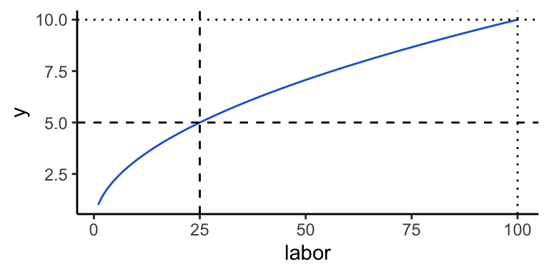

```r
tibble(labor = 1:100) |>
  ggplot(aes(x = labor)) + geom_function(fun = sqrt, color = "#2266DD") +
  theme_classic() +
  geom_vline(xintercept = 25, linetype = 2) +
  geom_vline(xintercept = 100, linetype = 3) +
  geom_hline(yintercept = 5, linetype = 2) +
  geom_hline(yintercept = 10, linetype = 3)
```

**NoteExample: Cobb-Douglas function**

The most straightforward example of a function that satisfies these conditions is the **Cobb-Douglas** function with constant returns to scale:

$$Y=AK^\alpha L^{1-\alpha}, \quad \alpha\in(0,1),$$
where $A>0$ is some constant that can relate to **technological capability** or **energy consumption**. The value $\alpha$ determines the relative importance of capital versus labor in output creation.
A generalization of Cobb-Douglas is $Y=AK^\alpha L^{\beta}$ with $\alpha+\beta \neq 1$…

## 2.2 What some data says

Now, let’s have a closer look - with **data**! From the general Cobb-Douglas function $Y = AK^aL^{b}$, we get:
$$\log(Y)=\log(A)+a \log(K)+b\log(L), \tag{1}$$

which is a perfect form for a **linear regression**!  
Below, we import the data and take a look at the univariate link between workforce size (proxy for labor) and GDP.

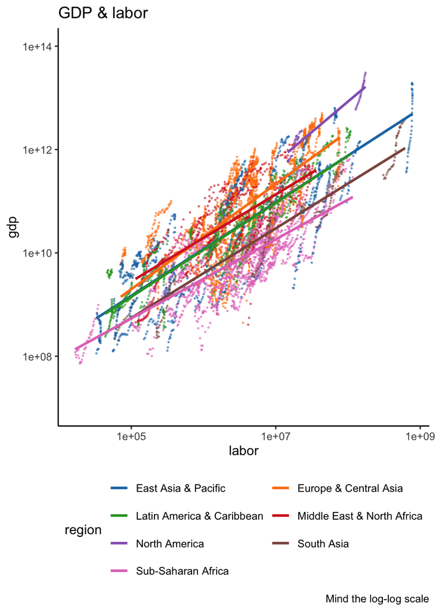

```r
wb_growth <- WDI(                           # World Bank data
  indicator = c(
    "labor" = "SL.TLF.TOTL.IN",             # Labor force (# individuals)
    "savings_rate" = "NY.GDS.TOTL.ZS",      # Savings rate (% GDP)
    "pop" = "SP.POP.TOTL",                  # Population
    "pop_growth" = "SP.POP.GROW",           # Population growth
    "capital_formation" = "NE.GDI.TOTL.ZS", # Gross capital formation (% GDP)
    "gdp_percap" = "NY.GDP.PCAP.CD",        # GDP per capita
    "gdp" = "NY.GDP.MKTP.CD"                # Gross Domestic Product (GDP)
  ),
  extra = TRUE,
  start = 1960,
  end = 2025) |>
  mutate(across(everything(), as.vector)) |>
  select(-status, -lending, -iso2c, -iso3c) |>
  filter(lastupdated == max(lastupdated)) |>
  arrange(country, year) |>
  mutate(capital_percap = capital_formation / labor)

wb_growth <- wb_growth |>
  filter(region != "Aggregates", income != "Aggregates") # Remove continents & co.

wb_growth |>
  ggplot(aes(x = labor, y = gdp, color = region)) + geom_point(size = 0.3, alpha = 0.5) +
  scale_x_log10() + scale_y_log10(limits = c(10^7, 10^14)) +
  geom_smooth(method = "lm", se = F) + theme_classic() +
  scale_color_d3() +
  theme(legend.position = "bottom") +
  guides(color = guide_legend(nrow = 4, byrow = TRUE)) +
  labs(title = "GDP & labor", caption = "Mind the log-log scale")
```

Gross capital formation is not necessarily exactly the best input, but it’s likely the one that is closest to a capital proxy in the World Bank data. So we use it anyway for the sake of providing some illustration.

**NoteCapital & investment**

Usually, we are interested in the **stock** of capital, and not flows (the net of additions minus subtractions). Often, we have the latter, which we write $I_t$. Because we must assume a depreciation rate $\delta$, the stock of capital is

$$K_t=(1-\delta)K_{t-1}+I_t, \tag{2}$$

where, depending on timing, $I_t$ can be replaced by $I_{t-1}$, and in the end,

$$K_t=(1-\delta)^tK_0 + \sum_{s=0}^tI_s (1-\delta)^{t-s}$$
But this still requires $K_0$…
**Note** that reasonable values for $\delta$ are ~5-6%, though in some industries, it could be higher (e.g.: the tech sector, for which obsolescence can come faster - see plot to the right: depreciation can reach -50% within 5-10 years).

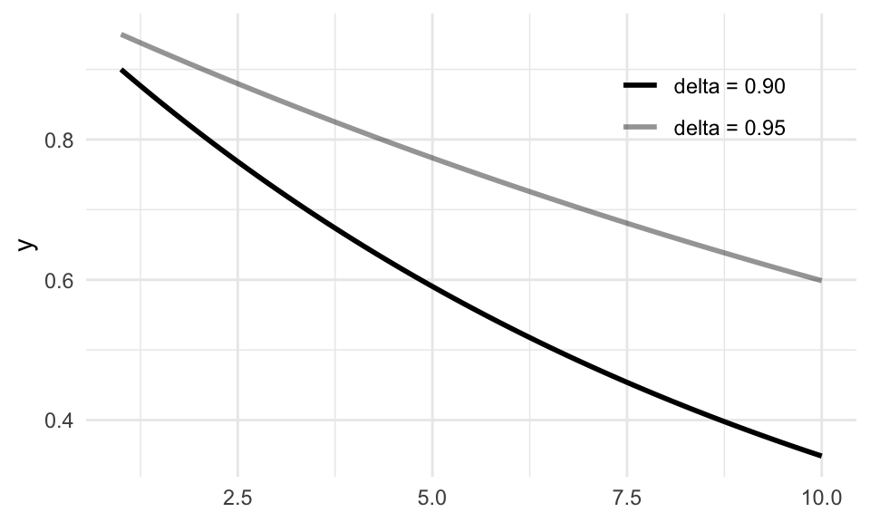

```r
ggplot() + xlim(c(1, 10)) +
  geom_function(fun = ~ 0.95^(.x), size = 1, aes(alpha = "delta = 0.95")) +
  geom_function(fun = ~ 0.90^(.x), size = 1, aes(alpha = "delta = 0.90")) +
  theme_minimal() + scale_alpha_manual(values = c(1, 0.42)) +
  theme(legend.position = c(0.8,0.8),
        legend.title = element_blank())
```

What about quantities per capita? Let’s look at our **capital** proxy.

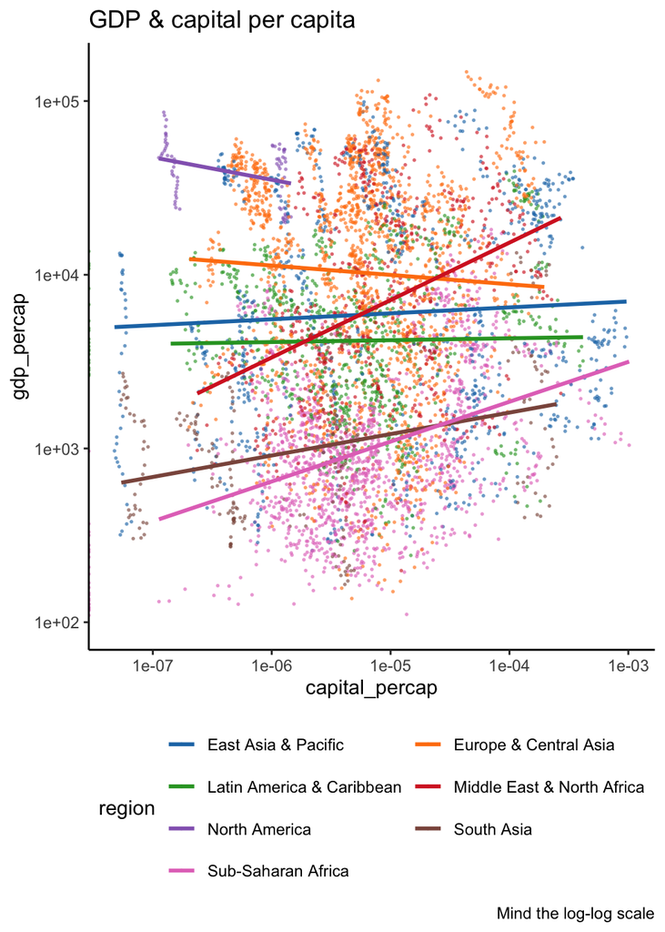

```r
wb_growth |>
  ggplot(aes(x = capital_percap, y = gdp_percap, color = region)) + geom_point(size = 0.3, alpha = 0.5) +
  scale_x_log10() + scale_y_log10(limits = c(100, 150000)) +
  geom_smooth(method = "lm", se = F) + theme_classic() +
  scale_color_d3() +
  theme(legend.position = "bottom") +
  guides(color = guide_legend(nrow = 4, byrow = TRUE)) +
  labs(title = "GDP & capital per capita", caption = "Mind the log-log scale")
```

We can then try to estimate the $a$ and $b$ constant in the model defined in Equation 1.

```r
lm(log(gdp) ~ log(labor) + log(capital_formation),
   data = wb_growth |>
     filter(gdp > 0, labor > 0, capital_formation > 0) |>
     select(gdp, labor, capital_formation) |> na.omit()) |>
  tbl_regression(intercept = T)
```

| **Characteristic** | **Beta** | **95% CI** | **p-value** |
| --- | --- | --- | --- |
| (Intercept) | 8.8 | 8.3, 9.2 | <0.001 |
| log(labor) | 0.93 | 0.91, 0.95 | <0.001 |
| log(capital_formation) | 0.48 | 0.39, 0.58 | <0.001 |

Abbreviation: CI = Confidence Interval

In this case, as we did not impose constant returns to scale, we see that the latter are in fact **increasing**… with the data & model (& estimation method) we use of course.

In fact, there are potentially large differences across countries and years; hence a **panel** model would be more suitable. Below, we enforce two-way **fixed effects** ($c_t$ to remove time-averages and $d_i$ to remove country-specific averages):

$$\log(Y_{t,i})= a\log(K_{t,i})+b\log(L_{t,i})+c_t+d_i+e_{t,i}.$$

```r
plm(
  formula = "log(gdp) ~ log(labor) + log(capital_formation)",
  data = wb_growth |>
    filter(gdp > 0, labor > 0, capital_formation > 0) |>
    mutate(country = as.factor(country)) |>
    select(gdp, labor, capital_formation, country, year) |> na.omit(),
  effect = "twoways",
  model = "within",
  index = c("country", "year")
) |>
  tbl_regression(intercept = T)
```

| **Characteristic** | **Beta** | **95% CI** | **p-value** |
| --- | --- | --- | --- |
| log(labor) | 0.47 | 0.41, 0.52 | <0.001 |
| log(capital_formation) | 0.16 | 0.13, 0.18 | <0.001 |

Abbreviation: CI = Confidence Interval

Here the results are **substantially** different - and seem to point towards decreasing returns to scale (the sum of coefficients is smaller than one).

## 2.3 A few simplifications

To further ease notations, we can use **constant returns** in the following way and focus on **per capita** output (e.g., assuming uniform competence across time and across the population). The idea is simply to equate labor and population and to write:

$$Y=F(K,L)= LF(K/L,1).$$
We can then think in terms of **per capita quantities**, which we write in lowercase letters: $y=Y/L$, $k=K/L$. The model becomes simply:
$$y = f(k),$$
and, for instance with a Cobb-Douglas production function, we get
$$y=Ak^\alpha.$$

This is simpler, as their is only one input and the important parameter, $\alpha$, features here only once!

## 2.4 Laws of motion

Until now, we have not mentioned an important dimension in models, **time**. Production occurs every year, but also every month, every week, and every day! First, let us fix things for **labor** (say, (active) population). The model is not intended to explain or focus on this particular variable, hence it makes a simple assumption:
$$L_t=L(t)=e^{nt}$$

We then introduce an important notation: the **differential operator** with respect to time, represented with a dot:
$$\dot{L}=\frac{\partial L}{\partial t}=ne^{nt} \quad \Longrightarrow \quad \frac{\dot{L}}{L}=n.$$

Clearly $n$ is the **growth rate of labor**. Usually, it is assumed nonnegative, but who knows what surprises the future will reveal? Some countries already experience degrowth in population…

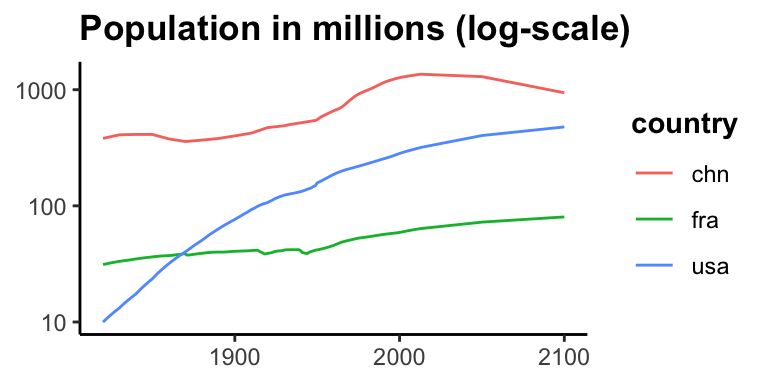

```r
url <- "https://raw.githubusercontent.com/open-numbers/ddf--gapminder--systema_globalis/master/countries-etc-datapoints/ddf--datapoints--total_population_with_projections--by--geo--time.csv"
pop <- read_csv(url)
colnames(pop) <- c("country", "year", "pop")
pop <- pop |> mutate(pop = pop / 10^6)

pop |>
  filter(country %in% c("fra", "usa", "chn"), year > 1800) |>
  ggplot(aes(x = year, y = pop, color = country)) +
  geom_line() + theme_classic() +
  theme(axis.title = element_blank(),
        title = element_text(face = "bold"),
        legend.title = element_text(face = "bold")) +
  ggtitle("Population in millions (log-scale)") +
  scale_y_log10()
```

The projections for 2100 reveal stark changes.

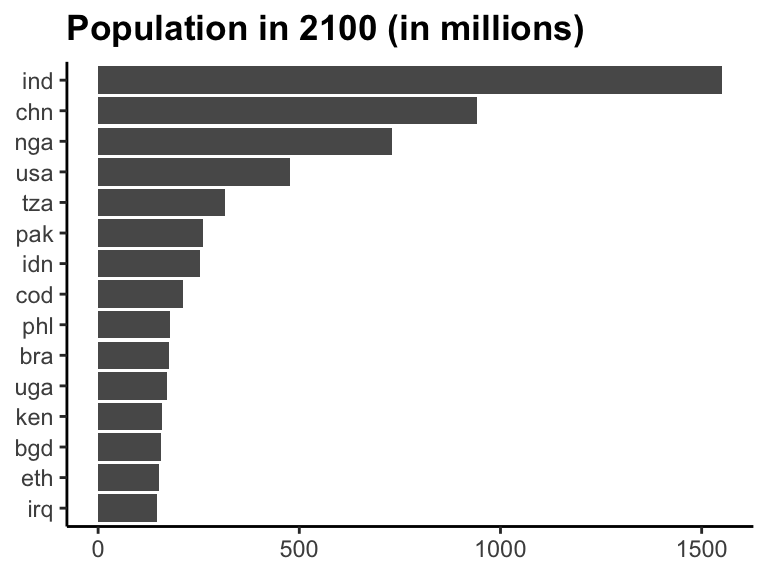

```r
pop |>
  filter(year == 2100) |>
  arrange(desc(pop)) |>
  head(15) |>
  ggplot(aes(x = pop, y = reorder(country, pop))) +
  geom_col() + theme_classic() +
  theme(axis.title = element_blank(),
        title = element_text(face = "bold"),
        legend.title = element_text(face = "bold")) +
  ggtitle("Population in 2100 (in millions)")
```

**NoteSide note on demographics**

**Demographic projections** are very important for many reasons (economic in particular).  
For recent elements on this topic, see the paper [The wealth of working nations](https://www.sciencedirect.com/science/article/pii/S0014292125000121) and the (related) video [The Demographic Future of Humanity](https://www.youtube.com/watch?v=f7_e_A_vFnk). In particular, it is argued that the size of the **working** population matters and that wealth (GDP) should be measured as the product of per-worker output times the number of active workers. When a population ages, this latter number usually shrinks slowly, thus the ratio GDP/workers is perhaps more relevant than GDP/population.

In addition, $n$ is fixed exogenously, but there are models that endogenize it so that it is determined/constrained by other factors. For instance, we’ll see later that agents can choose to allocate their time between working and taking care of children.

**TipAbout the dot $\dot{L}$ notation**

The dot notation $\dot{L}$ stands for the derivative of the $L$ function with respect to **time**. It is the infinitesimal increase of $L$ when $t$ (time) increasing by just a tiny bit. $\dot{L}_t=\frac{\partial L_t}{\partial t}$. Importantly, this assumes that **time is continuous**. This is somewhat far-fetched when we think in terms of data, as many indicators are only available on a yearly basis, with a few at the monthly frequency (e.g., inflation).

Nevertheless, with the advent of big data and nowcasting, higher frequencies are becoming more common. For instance, the OECD used to propose a [*real-time* GDP tracker](https://web-archive.oecd.org/sections/weekly-tracker-of-gdp-growth/index.htm) that was updated at a weekly rate, but it seems this project was suspended (until some hypothetical future update).

The [Atlanta FED](https://www.atlantafed.org/), though, seems to have a [weekly GDP tracker](https://www.atlantafed.org/cqer/research/gdpnow).

The most interesting part of the model pertains to **capital** (it’s the only variable driving output). Indeed, we have:
$$\dot{y}=\frac{\partial }{\partial t}Ak(t)^\alpha = \alpha A \dot{k} k^{\alpha-1}=\alpha A \dot{k}\frac{k^\alpha}{k}=\alpha \frac{\dot{k}}{k}y \quad \Leftrightarrow \quad \frac{\dot{y}}{y}=\alpha \frac{\dot{k}}{k} .$$

The (relative) growth rate of output is proportional to that of capital (per capita).

It is assumed that capital dynamics are driven by two opposite forces: **investment** (in production apparatus) and **capital depreciation**:

$$\dot{K}=\frac{\partial K}{\partial t}= sY-\delta K \ \Leftrightarrow \ \frac{\dot{K}}{L}=sy-\delta k , \tag{3}$$

where $s \in [0,1]$ is called the **savings rate** and measures how much of the current output value is **reinvested** (in the economy as a whole here). The constant $\delta>0$ is the rate at which capital value decays.

Now, it’s easier to use the simple model, the one that considers *per capita* quantities. What’s the law of motion of $K/L$? Because $\dot{L}=n L$, it’s
$$\dot{k}=\frac{\partial (K/L)}{\partial t}=\frac{\dot{K}L-K\dot{L}}{L^2}=\frac{\dot{K}-Kn}{L}=\dot{K}/L-kn.$$
If we plug this into (Equation 3), we get
$$\dot{k}=sy - k (\delta + n), \tag{4}$$

where we see that the dynamics of per capita capital is: saved capital minus a **depreciation rate** $\delta + n$. Intuitively, if the population grows at rate $n$, then the quantity per capita should decrease at rate $n$, too.

### 2.4.1 Illustration

Below, we seek to depict the above relationship. We fix:  
- a **savings rate** of $s=10\%$,  
- a **population growth** of $n=0.02$,  
- a **depreciation rate** of $\delta=0.05$.

And we work with $\alpha = 1/2$ and $A=1$ for simplicity. We plot the two terms and where they cross is a point of stability (see below).

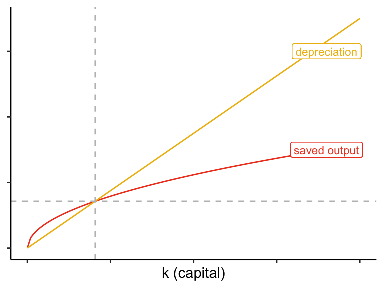

```r
s <- 0.1
n_delta <- 0.07
k_star <- (s/(n_delta))^2
tibble(x = 0:10) |>
  ggplot(aes(x = x)) +
  geom_function(fun = function(x) 0.1*(x^0.5), color = "#EE4422") +
  geom_function(fun = function(x) 0.07*x, color = "#EEBB11") +
  theme_classic() + xlab("k (capital)") +
  theme(axis.title.y = element_blank(),
        axis.text = element_blank()) +
  geom_vline(xintercept = k_star, linetype = 2, color = "grey") +
  geom_hline(yintercept = sqrt(k_star)*s, linetype = 2, color = "grey") +
  geom_label(aes(x = 9, y = 0.3), label = "saved output", color = "#EE4422", size = 3, fill = "white") +
  geom_label(aes(x = 9, y = 0.6), label = "depreciation", color = "#EEBB11", size = 3, fill = "white")
```

# 3 Steady states

## 3.1 Balanced growth paths, focused on **capital**

**Balanced growth paths** (BGP) are parameter combinations that lead to **constant (relative) growth rates**. Because the key quantities (growth rates) do not change anymore, this can be perceived as a form of **equilibrium**. We are interested in these situations as they characterizes stable versions of the model - they are also called **steady states**. For instance, in the specification outlined above, this would mean that $\dot{k}/k$ is constant. Given Equation 4, it is equal to
$$\gamma_k=\frac{\dot{k}}{k}=\frac{sy}{k}-(n+\delta)=Ask^{\alpha-1}-(n+\delta), \tag{5}$$
hence, we see that the relative rate still depends on $k$. For it to be constant, we would need $k$ to be constant too and thus, this requires $\dot{k}=0$ (except in the **exceptional configuration** where $\alpha = 1$)! If $\alpha \neq 1$, the BGP implies that all quantities be constant, which seems rather *unrealistic* in practice, but anyhow, it’s an interesting exercise.

**ImportantThe main takeaway**

This leads to the main conclusion: the **Solow models does not generate endogenous growth in equilibrium**!

In the above example, the **equilibrium point** is where the red and yellow curves meet, i.e., where the increase obtained from the **saved output** is offset by the **natural depreciation** of the capital.

If we take the Cobb-Douglas example, for which $y=Ak^a$, the condition is $sy - k (\delta + n)=0$, i.e,
$$sAk^a=k(\delta +n) \Longleftrightarrow k^{a-1}=\frac{\delta + n}{sA} \Longleftrightarrow k^*=\left(\frac{sA}{\delta + n} \right)^{1/(1-a)} \tag{6}$$

Below, we plot $sy/k$ and $n+\delta=0.01+0.05=0.06$ (population growth and capital depreciation), with $y=Ak^{1/2}$, $A=1$ and $s=0.1$. The point where the curves cross is $s/k^{1/2}=n+d$, i.e., $k=(s/(n+d))^2$ in our example. It marks the zone where capital will increase versus the one where it will shrink.

```r
n_d <- 0.06
a <- 0.5
s <- 0.1
solution <- (s/n_d)^2
```

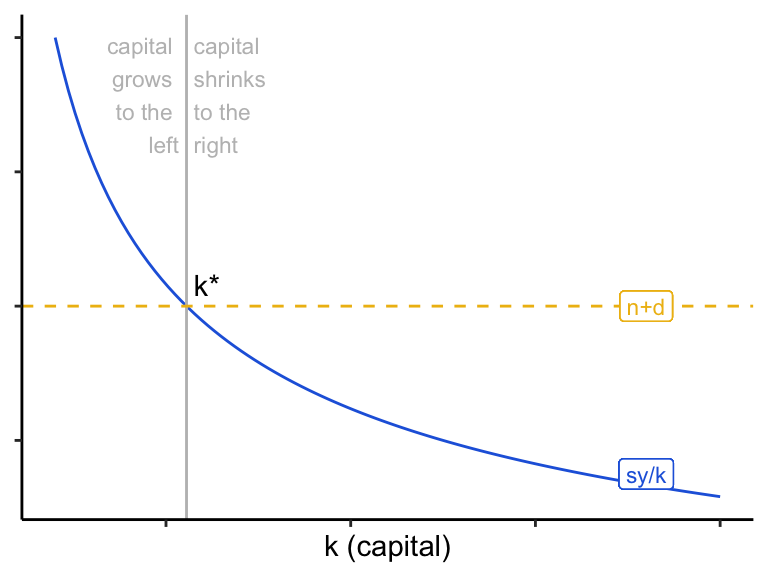

```r
tibble(x = 1:10) |>
  ggplot(aes(x = x)) + geom_function(fun = function(x) (s/(x^a)), color = "#2266DD") +
  theme_classic() + xlab("k (capital)") +
  theme(axis.title.y = element_blank(),
        axis.text = element_blank()) +
  geom_vline(xintercept = solution, color = "grey") +
  annotate("text", label = "capital \nshrinks \nto the \nright", vjust = 1,
           x = solution + 0.1, y = s, color = "grey", hjust = 0, size = 3) +
  annotate("text", label = "capital \ngrows \nto the \nleft", vjust = 1,
           x = solution - 0.1, y = s, color = "grey", hjust = 1, size = 3) +
  geom_hline(yintercept = n_d, linetype = 2, color = "#EEBB11") +
  annotate("text", label = "k*", x = solution + 0.1, y = n_d, hjust = 0, vjust = -0.5) +
  geom_label(aes(x = 9, y = 0.035), label = "sy/k", color = "#2266DD", size = 3, fill = "white") +
  geom_label(aes(x = 9, y = n_d), label = "n+d", color = "#EEBB11", size = 3, fill = "white")
```

We recall that, in the model, the **capital**, $k$, is the key driver of growth. Its growth rate, $\gamma_k$ is given in Equation 5.

To reach the steady state (BGP), it is required that $\dot{k}>0$ when $k<k^*$ or $\dot{k}<0$ when $k>k^*$. In both cases, this means that, taken exactly at the optimal $k^*$, the derivative with respect to $k$ is negative:

$$\left. \frac{\partial \dot{k}}{\partial k} \right|_{k=k^*}<0.$$
In the Cobb-Douglas model, from (Equation 4), we have

$$\frac{\partial \dot{k}}{\partial k}=sy'(k)- (n+\delta) = s (A\alpha k^{\alpha -1}) - (n+\delta),$$
and substituting (Equation 6),

$$sA\alpha \left( \left(\frac{sA}{\delta + n} \right)^{1/(1-a)} \right) ^{\alpha-1}-(n+\delta)=sA\alpha\left(\frac{sA}{n+\delta} \right)^{-1}-(n+\delta)=(\alpha-1)(n+\delta).$$
To be negative (assuming $n+\delta>0$), this expression requires $\alpha <1$, i.e., **diminishing returns**.

## 3.2 Sensitivity analysis

What if the output increases, e.g., if the **productivity factor** $A$ becomes larger by 30%? For instance, this could come from a technological shock (boost). Imagine something like the **internet** in the 1990s-2000s… or **artificial intelligence**?

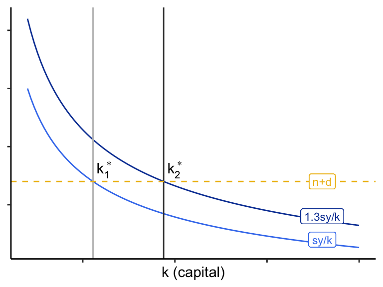

```r
tibble(x = 1:10) |>
  ggplot(aes(x = x)) + theme_classic() + xlab("k (capital)") +
  geom_function(fun = function(x) (s/(x^a)), color = "#427FEE") +
  geom_function(fun = function(x) (1.3*s/(x^a)), color = "#0B42A3") +
  theme(axis.title.y = element_blank(),
        axis.text = element_blank()) +
  geom_vline(xintercept = solution, color = "grey") +
  geom_vline(xintercept = (1.3*s/n_d)^2, color = "#444444") +
  geom_hline(yintercept = n_d, linetype = 2, color = "#EEBB11") +
  annotate("text", label = TeX("$k_1^*$"), x = solution + 0.1, y = n_d, hjust = 0, vjust = -0.2) +
  annotate("text", label =  TeX("$k_2^*$"), x =  (1.3*s/n_d)^2 + 0.1, y = n_d, hjust = 0, vjust = -0.2) +
  geom_label(aes(x = 9, y = 0.035), label = "sy/k", color = "#427FEE", size = 3, fill = "white") +
  geom_label(aes(x = 9, y = 0.045), label = "1.3sy/k", color = "#0B42A3", size = 3, fill = "white") +
  geom_label(aes(x = 9, y = n_d), label = "n+d", color = "#EEBB11", size = 3, fill = "white")
```

## 3.3 What about consumption?

In the model, **consumption** is what is not saved, i.e., $c=(1-s)y$.

Upon equilibrium, the growth rate in Equation 5 is equal to zero, hence
$$sy^* =k^*(\delta+n) \tag{7}$$
and long-term consumption is
$$c^*=y^*-(\delta + n)k^*,$$
but in this expression, $y^*$ and $k^*$ depend on the savings rate $s$; see for instance Equation 6: $k^*=\left(\frac{sA}{\delta + n} \right)^{1/(1-a)}$. The long-term (steady) consumption can thus be influenced by $s$. Since $y=Ak^a$, this gives
$$c^*= A\left(\frac{sA}{\delta + n} \right)^{a/(1-a)}-(\delta+n)\left(\frac{sA}{\delta + n} \right)^{1/(1-a)}.$$

We illustrate this shape in the plot to the right. We see that there is in fact an **optimal level** for $s$… perhaps this should be endogenized directly within the model with agents that maximize their consumption stream (more on that later!).

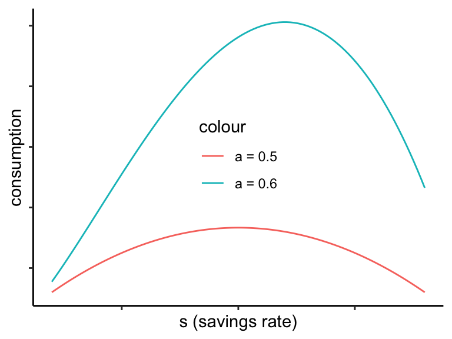

```r
c_star <- function(s, a, A, d_n){
  A*(s*A/n_d)^(a/(1-a)) - n_d*(s*A/n_d)^(1/(1-a))
}

tibble(s = seq(0.1,0.9, by = 0.1)) |>
  ggplot(aes(x = s)) + theme_classic() + xlab("s (savings rate)") + ylab("consumption") +
  geom_function(fun = c_star, args = list(a = 0.5, A = 1, d_n = 0.06), aes(color = "a = 0.5")) +
  geom_function(fun = c_star, args = list(a = 0.6, A = 1, d_n = 0.06), aes(color = "a = 0.6")) +
  theme(legend.position = c(0.5, 0.5),
        axis.text = element_blank())
```

# 4 The cross-section of wealth (first look)

Ok, so the model is not great at generating stable long-term growth. But maybe it can explain **differences in GDP per capita** across countries…

We recall the optimal from Equation 7 and Equation 6:
$$y^*=A^{1/(1-\alpha)}\left( \frac{s}{n+\delta} \right)^{\alpha/(1-\alpha)}.$$

If we take the log,

$$\log(y^*) = \frac{1}{1-\alpha}\log(A) + \frac{\alpha}{1-\alpha}\log\left(\frac{s}{n+\delta} \right)$$

Capital depreciation is hard to measure, so let’s fix it at $\delta=0.1$ for all countries (a slightly high value).  
Now, let’s see what the data tells us: is the above formula reliable or not?

```r
wb_growth <- wb_growth |>
  group_by(country) |>
  mutate(pop_growth = mean(pop_growth, na.rm = T)) |>
  ungroup() |>
  mutate(x = log(savings_rate/(0.1 + pop_growth)))
lm(log(gdp_percap) ~ x,
   data = wb_growth |>
     filter(gdp_percap > 0, x > 0) |>
     select(gdp_percap, x) |> na.omit()) |>
  tbl_regression(intercept = T)
```

| **Characteristic** | **Beta** | **95% CI** | **p-value** |
| --- | --- | --- | --- |
| (Intercept) | 5.6 | 5.5, 5.7 | <0.001 |
| x | 0.95 | 0.92, 0.98 | <0.001 |

Abbreviation: CI = Confidence Interval

If we use time-series data to estimate country-specific $\alpha$ and $A$ (total productivity factor), from {capital_percap} directly.

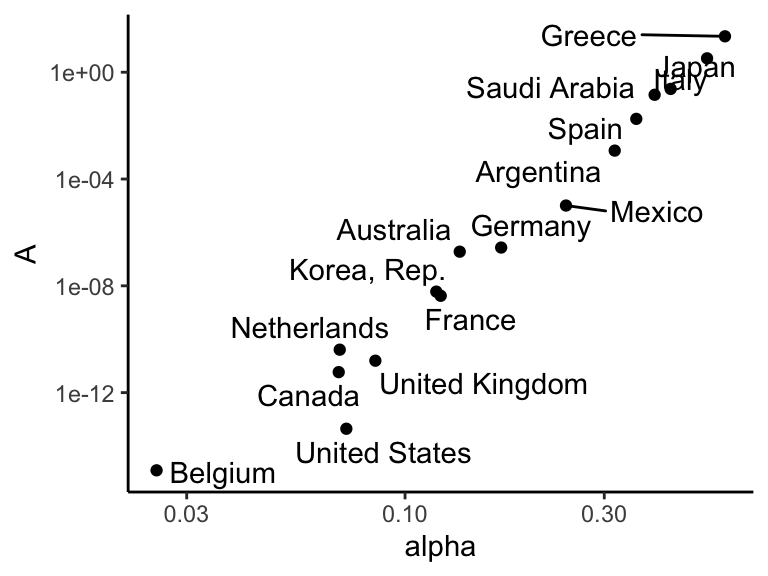

```r
wb_growth |>
  filter(gdp_percap > 4000, is.finite(capital_percap), pop > 10^7) |>
  group_by(country) |>
  mutate(n = n()) |>
  filter(n > 32) |>
  group_by(country) |>
  regress(log(gdp_percap) ~ log(capital_percap), m("lm")) |>
  coef() |>
  select(country, term, estimate) |>
  pivot_wider(names_from = "term", values_from = "estimate") |>
  mutate(alpha = exp(`log(capital_percap)`),
         A = exp(`(Intercept)`)) |>
  filter(alpha > 0.01, alpha < 0.99) |>
  ggplot(aes(x = alpha, y = A)) + geom_point() + geom_text_repel(aes(label = country)) +
  scale_x_log10() + scale_y_log10() + theme_classic()
```

We only show the countries for which $\alpha \in (0,1)$ but even this leads to $A$ taking very different values.  
Somewhat surprisingly, the link between the two values is positive.

Lastly, let’s try a hybrid approach via a panel model in which the alpha will be common to all countries but the fixed effects coding the $A_i$ differ…

```r
fit <- plm(
  formula = "log(gdp_percap) ~ x",
  data = wb_growth |>
    filter(gdp_percap > 0, labor > 0, savings_rate > 0) |>
    mutate(country = as.factor(country)) |>
    mutate(x = log(savings_rate/(0.05 + pop_growth))) |>
    select(gdp_percap, labor, country, year, x) |> na.omit(),
  effect = "twoways",
  model = "within",
  index = c("country")
)
fit |>  tbl_regression(intercept = T)
```

| **Characteristic** | **Beta** | **95% CI** | **p-value** |
| --- | --- | --- | --- |
| x | 0.11 | 0.09, 0.12 | <0.001 |

Abbreviation: CI = Confidence Interval

The result is very different again. $\alpha$ is surprisingly low. The **productivity factors** reflect variations in GDP per capita.

```r
alpha <- 0.08/(1+0.08)
exp(fixef(fit)*(1-alpha)) |> as.list() |> data.frame() |>
  pivot_longer(everything(), names_to = "country", values_to = "A") |>
  head(12)
```

| country | A |
| --- | --- |
| Albania | 825.1893 |
| Algeria | 658.4669 |
| Angola | 810.2186 |
| Argentina | 1646.1472 |
| Armenia | 839.6233 |
| Australia | 6330.2224 |
| Austria | 5786.0799 |
| Azerbaijan | 450.5500 |
| Bahamas..The | 4421.3688 |
| Bahrain | 3487.5553 |
| Bangladesh | 177.2414 |
| Belarus | 587.2981 |

# 5 Simulation: a try

$$\dot{k}_t=s Ak_t^\alpha - k_t (\delta + n),$$

A simulation is not necessarily obvious; here we follow the [**Euler discretization scheme**](https://en.wikipedia.org/wiki/Euler_method) (with unit step) and use $A=1$.  
We wrap the code in a function that depends on the important parameters and we allow for some randomness (just out of curiosity). This randomness is coded with the function `rnorm` (Gaussian noise).

```r
s <- 0.1       # Savings rate
delta <- 0.05  # Capital depreciation
n <- 0.02      # Population growth
alpha <- 0.8   # Cobb-Douglas parameter
n_k <- 100     # Number of points (time-steps)
gen_k <- function(alpha, s, delta, n, sigma, n_k){
  k_dot <- 0
  k <- 100     # Initial value = starting point
  for(t in 2:n_k){
    k_dot[t] <- s*k[t-1]^alpha - k[t-1]*(delta+n) + sigma*rnorm(1)
    k[t] <- k[t-1] + k_dot[t]
  }
  k
}
```

# 6 Takeaways

$\rightarrow$ The **Solow model** does not generate (steady) growth endogenously.  
It is not reable able to produce some of the most salient stylized facts in macroeconomics…  
The next sessions will try to propose extensions that intend to address these limitations.

# 7 BONUS: the labor share

## 7.1 The data

The figure below plots the labor share of the U.S. corporate sector, defined as

$$\text{Labor share}_t = \frac{\text{Compensation of employees}_t}{\text{Gross value added of corporate business}_t} \times 100,$$

using annual averages of quarterly data from **BEA NIPA Table 1.14** (*Gross Value Added of Domestic Corporate Business*), retrieved via FRED (series `A442RC1Q027SBEA` and `A451RC1Q027SBEA`).

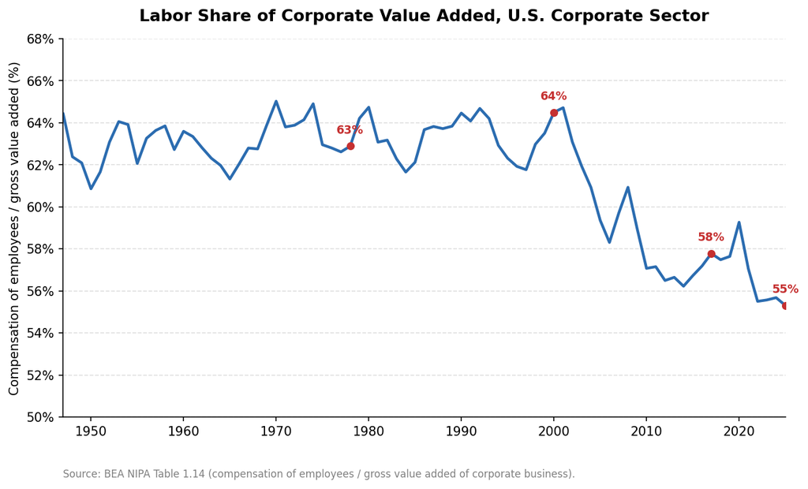

Figure 1

### 7.1.1 What’s driving the decline?

[Zidar and Zwick](https://everywheremillionaire.substack.com/p/why-the-labor-share-keeps-falling) argue that a substantial share of the post-2000 decline in labor’s share is a measurement artifact created by the tax code rather than a real shift in production. After the Tax Reform Act of 1986 lowered individual rates relative to corporate rates, owners increasingly converted from C corporations to S corporations and reported income as profit rather than wages; the Affordable Care Act’s 3.8% net investment income surtax further strengthened this incentive for high earners. Because national accounts classify S-corporation profits as capital income, this relabeling mechanically reduces the measured labor share without changing underlying production.

A related effect is the migration of labor-intensive businesses (law firms, consultancies, medical practices, and hedge funds) into partnerships, whose profits rose from 13% of business profits in 1980 to 35% today. Since these firms have higher labor shares than the corporate sector they left, their exit makes corporations appear more capital-intensive. Correcting for both effects, the authors estimate that about one-third of the 1978–2017 decline in the labor share (1.6 of 5.0 percentage points) reflects tax-driven income reclassification rather than a genuine economic shift, and they argue that the 2017 Tax Cuts and Jobs Act’s Section 199A deduction (made permanent by the 2025 ‘One Big Beautiful Bill Act’) has further reinforced these incentives.

## 7.2 Why this connects to Cobb-Douglas

The Cobb-Douglas production function,

$$Y = A K^{\alpha} L^{1-\alpha}, \qquad 0 < \alpha < 1,$$

is the workhorse of growth theory largely *because* it reproduces one of Kaldor’s stylized facts: a stable labor share. If firms are price takers and pay each factor its marginal product, the wage bill is

$$w L = \frac{\partial Y}{\partial L} L = (1-\alpha) Y,$$

so the labor share is exactly the constant exponent $(1-\alpha)$. Under Cobb-Douglas, this ratio is **invariant to capital deepening**: however much $K/L$ rises, $(1-\alpha)$ does not move. This is a direct algebraic property of the unit elasticity of substitution between capital and labor embedded in the Cobb-Douglas form.

The 1947-2000 portion of Figure 1 is broadly consistent with this: the labor share fluctuates cyclically but shows no clear trend, which is exactly what a Cobb-Douglas economy with a roughly constant $\alpha$ would predict. The post-2000 decline is not.

## 7.3 Generalizing with a CES production function

A constant-elasticity-of-substitution (CES) production function nests Cobb-Douglas as a special case and allows the labor share to move with the capital-labor ratio:

$$Y = A\left[\alpha K^{\frac{\sigma-1}{\sigma}} + (1-\alpha) L^{\frac{\sigma-1}{\sigma}}\right]^{\frac{\sigma}{\sigma-1}},$$

where $\sigma$ is the elasticity of substitution between capital and labor. Cobb-Douglas corresponds to $\sigma \to 1$. Under CES with competitive factor markets, the labor share satisfies

$$\frac{wL}{Y} = (1-\alpha)\left(\frac{Y}{AL}\right)^{\frac{1-\sigma}{\sigma}},$$

so it depends on labor productivity $Y/L$ whenever $\sigma \neq 1$ (the exponent vanishes exactly when $\sigma = 1$, recovering the constant Cobb-Douglas share $1-\alpha$):

- If $\sigma > 1$, capital and labor are relatively easy substitutes, and a rising capital-labor ratio **lowers** the labor share.
- If $\sigma < 1$, capital deepening **raises** the labor share.

[Karabarbounis and Neiman (2014)](https://academic.oup.com/qje/article-abstract/129/1/61/1899422) is the reference estimate here: they argue $\sigma > 1$ for the U.S. and attribute much of the observed decline to a falling relative price of investment goods (i.e., cheaper capital equipment), which induces firms to substitute capital for labor.

## 7.4 Caveats

These explanations are not mutually exclusive, and disentangling them is largely an empirical exercise in firm- and industry-level data rather than something readable off the aggregate time series alone.

**GOING FURTHER**: [A Standard Task-Based Solow Model Delivers AI-Driven Double-Digit Growth](https://benjaminmoll.com/wp-content/uploads/2026/09/task_based_solow.pdf)